# Combining images with ggplot plots

Baboyma Kagniniwa

2024-12-11

[figure not shown]

## Background

This post was developed in response to an inquiry / suggestion to add a new function to `glitr` package that will be used to add **logos** to ggplot plots. After review of the inquiry, we decided it was best to show examples of ggplot plotting where [`cowplot Package`](https://wilkelab.org/cowplot/index.html) and other plotting packages ([patchwork](https://www.tidyverse.org/tags/patchwork/)) could be used to accomplish the same goal.

## Objectives

We will cover 4 main points:

1. Visualize data with ggplot
2. Combine multiple plot into 1
3. Add ggplot plots to images (png files)
4. Add images (png files) to ggplot plots

## Requirements

For the demo, we will be using `tidyverse`, `patchwork`, `cowplot` and other core OHA Packages.

```r
  library(tidyverse)
  library(gagglr)    # Used to read MSD and and plot viz
  library(tidytext)
  library(ggtext)    # Used for rich text formating
  library(scales)    # Used to format labels and scales
  library(patchwork) # Combine and arrange multiple plots
  library(cowplot)   # use ggdraw to add plots on top of each other
  library(glue)      # Used to replace variable values in text
```

Let’s start by defining our **data path** and other **key global parameters**. We will also need to download or get the links to publicly available images / logos.

```r
  ## Directory holding all the MSDs files
  dir_mer <- glamr::si_path("path_msd")
  dir_mer <- file.path("..", dir_mer) # The .. is only needed in this case because the markdown file is not in the current directory of the project. Skip if you are running this from a R file.

  # Params
  ref_id <- "0ca8dae2"
  cntry <- "Minoria"
  agency <- "USAID"
```

For this demo, we will be using **training data** (PSNU x IM) from [themask](https://usaid-oha-si.github.io/themask/) package.

```r
  # Check data availability
  themask::msk_available()
```

```
## The latest available masked dataset is 'PSNU_IM_FY59-62_20241115_v1_1'
## All available masked dataset for download:
## ✔ 2024.11.15.i [latest]
##
## • 2024.08.16.i
##
## • 2024.06.14.c
##
## • 2024.05.17.i
##
## • 2024.03.15.c
##
## • 2024.02.15.i
##
## • 2023.11.14.i
##
## • 2023.09.15.c
##
## • 2023.06.16.c
##
## By default, the latest file is downloaded but you can specify the version from
## above list in the tag param of `msk_download()`
```

```r
  # Download the latest available dataset - ONLY IF NEEDED
  themask::msk_download(folderpath = dir_mer, tag = "latest")
```

```r
  # Check list of files within the directory
  dir_mer %>%  fs::dir_ls()
```

Let’s retrieve the full path of the training data set.

```r
  # Full path of data file
  file_training <- return_latest(
    folderpath = dir_mer,
    pattern = "TRAINING"
  )
```

Now that we have the path of our data set, let’s grab all the metadata. These will be used, later on for data munging and visualization.

```r
  meta <- get_metadata(path = file_training)
```

```
## ℹ You must store the output as an object to use, e.g. `meta <- get_metadata()`
```

```r
  meta
```

```
## $curr_pd
## FY61Q3
##
## $curr_fy
## [1] 2061
##
## $curr_fy_lab
## FY61
##
## $curr_qtr
## [1] 3
##
## $source
## FY61Q3i Faux Training MSD
##
## $caption
## Source: FY61Q3i Faux Training MSD | Ref id: 0ca8dae2
```

For images, let’s get links of `glitr`’s logo, and World AIDS Day images from [Care Resource](https://careresource.org/) and [iStockPhoto](https://www.istockphoto.com/). These will be used as logo and or backgrounds.

```r
  # Glitr Logo
  file_logo <- "https://usaid-oha-si.github.io/glitr/reference/figures/logo.png"
  # AIDS Day
  file_aids <- "https://careresource.org/wp-content/uploads/2023/11/WAD-2023-300x300.png"
  # AIDS Robban
  file_aids_rubon <- "https://media.istockphoto.com/id/855766998/vector/world-aids-day.jpg?s=612x612&w=0&k=20&c=yDXRBawjxGBhwJumB6QOHsYg2_r0IYEL1gcRqatvODQ="
```

## Load and Explore Data

`gophr::read_psd()` is still our go to function for all **PEPFAR Structured Datasets**

```r
  # Read content of the PSNU x IM as a data frame
  df_msd <- file_training %>% read_psd()
```

```r
  # Explore content of the data - countries and funding agency
  df_msd %>% distinct(country, funding_agency)
```

```
## # A tibble: 3 × 2
##   country funding_agency
##   <chr>   <chr>
## 1 Minoria HHS/CDC
## 2 Minoria USAID
## 3 Minoria Dedup
```

```r
  # Explore content of the data - indicators
  df_msd %>%
    filter(fiscal_year == meta$curr_fy,
           str_detect(indicator, "HTS_TST")) %>%
    distinct(indicator, standardizeddisaggregate) %>%
    arrange(indicator)
```

```
## # A tibble: 6 × 2
##   indicator   standardizeddisaggregate
##   <chr>       <chr>
## 1 HTS_TST     Modality/Age/Sex/Result
## 2 HTS_TST     KeyPop/Result
## 3 HTS_TST     Total Numerator
## 4 HTS_TST_POS Modality/Age/Sex/Result
## 5 HTS_TST_POS KeyPop/Result
## 6 HTS_TST_POS Total Numerator
```

## Data Munging

For this case, we will focus on HTS Results. Let’s summarize testing data by PSNU and for 2061 fiscal year.

```r
  # Summary of HTS Indicator
  df_hts <- df_msd %>%
    filter(fiscal_year == meta$curr_fy,
           country == cntry,
           funding_agency == agency,
           indicator %in% c("HTS_TST", "HTS_TST_POS"),
           standardizeddisaggregate == "Total Numerator") %>%
    summarise(value = sum(cumulative, na.rm = T),
              .by = c(country, psnu, indicator))

  # Calculate positivity rates at PSNU level
  df_hts <- df_hts %>%
    summarise(value = value[indicator == "HTS_TST_POS"] / value[indicator == "HTS_TST"],
              .by = c(country, psnu)) %>%
    mutate(indicator = "HTS_TST_YIELD") %>%
    bind_rows(df_hts, .)
```

## Visualization

ggplot works well with `tidy datasets` but there are situation where we go back to a `wider format` to simplify the code. It’s common to see 2 or more versions of the same data in a project and/or script.

### Reshaping data based on the type of visual

```r
  df_viz <- df_hts %>%
      pivot_wider(
        names_from = indicator,
        values_from = value
      )
```

### 1) Visualize data with ggplot

```r
  # Title & Subtitle
  plot_title <- glue("{meta$curr_pd} - {toupper(cntry)} HIV TESTING SERVICES")
  plot_subtitle <- glue("As of **{meta$curr_pd}**, {cntry} reported **{comma(sum(df_viz$HTS_TST_POS))} HIV+** out of **{comma(sum(df_viz$HTS_TST))}** from **{length(unique(df_viz$psnu))} PSNUs**")

  plot_subtitle
```

```
## As of **FY61Q3**, Minoria reported **3,593 HIV+** out of **320,409** from **9 PSNUs**
```

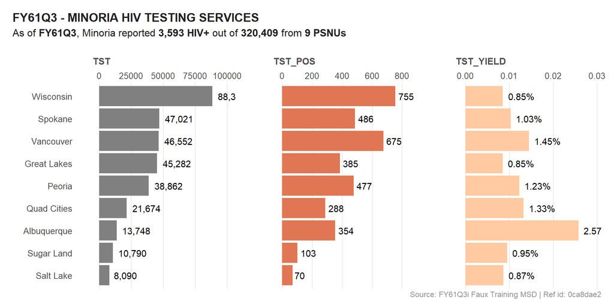

```r
  # VIZ - HTS POS
  viz_hts <-
    df_hts %>%
      # pre-format labels before facet_wrap()
      mutate(
        label = case_when(
          indicator == "HTS_TST_YIELD" ~ percent(value, 0.01),
          TRUE ~ comma(value, 1)
        )
      ) %>%
      ggplot(aes(x = value, y = reorder(psnu, value), fill = indicator)) +
      geom_col(show.legend = F) +
      geom_text(aes(label = label, hjust = -0.2)) +
      scale_fill_manual(
        values = c(
          "HTS_TST" = trolley_grey,
          "HTS_TST_POS" = burnt_sienna,
          "HTS_TST_YIELD" = burnt_sienna_light
        )
      ) +
      scale_x_continuous(position = "top", expand = c(0.2,0)) +
      facet_wrap(~str_replace(indicator, "HTS_", ""),
                 nrow = 1, scales = "free_x") +
      labs(x = "", y = "",
           title = plot_title,
           subtitle = plot_subtitle,
           caption = meta$caption) +
      si_style_xgrid() +
      theme(legend.title = element_blank(),
            plot.title = element_markdown(),
            plot.subtitle = element_markdown(),
            strip.placement = "outside",
            strip.text = element_text(face = "bold", hjust = .1),
            strip.clip = "off")

  viz_hts
```

We could also drop the calculated indicator (HTS_TST_YIELD) and focus only on HTS_TST and HTS_TST_POS, given that these are absolute numbers.

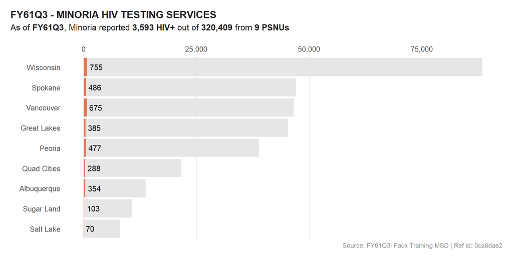

```r
  # VIZ - HTS POS
  viz_hts_pos <-
    df_viz %>%
      ggplot(aes(y = reorder(psnu, HTS_TST))) +
      geom_col(aes(x = HTS_TST), fill = trolley_grey_light, show.legend = T) +
      geom_col(aes(x = HTS_TST_POS), fill = burnt_sienna, show.legend = T) +
      geom_text(aes(x = HTS_TST_POS, label = comma(HTS_TST_POS)), hjust = -0.2) +
      scale_x_continuous(labels = comma, position = "top") +
      labs(x = "", y = "",
           title = plot_title,
           #title = glue("<span style='line-height:50px;display:inline-block;border-width:3px;border-color:red;'></span>{meta$curr_pd} - {toupper(cntry)} HIV TESTING SERVICES"),
           subtitle = plot_subtitle,
           caption = meta$caption) +
      si_style_xgrid() +
      theme(legend.title = element_blank(),
            plot.title = element_markdown(),
            plot.subtitle = element_markdown())

  viz_hts_pos
```

In preparation of the next steps, we will try to remove the background of some of the plots so that the overlay is clear.

Below we leverage `si_style_transparent()` on a bar chart of HTS_TST_POS. We’ve also used `facet_wrap()` with margin and spacing adjustments to add the PSNU names on top of the bar.

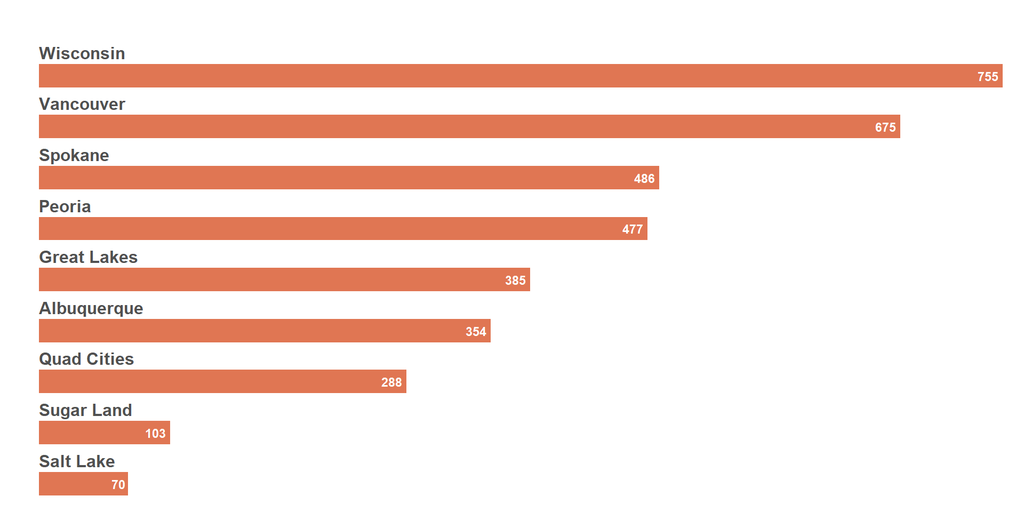

```r
  viz_hts_pos2 <-
    df_viz %>%
    mutate(psnu = fct_reorder(psnu, -HTS_TST_POS)) %>%
    ggplot(aes(y = psnu)) +
    geom_col(aes(x = HTS_TST_POS), fill = burnt_sienna, width = 1, show.legend = T) +
    geom_text(aes(x = HTS_TST_POS, label = comma(HTS_TST_POS, 1)),
              fontface = "bold", color = "#FFF", size = 3, hjust = 1.2) +
    scale_x_continuous(labels = percent, position = "top", expand = c(0, 0)) +
    scale_y_discrete(guide = "none") +
    facet_wrap(~psnu, ncol = 1, scales = "free_y") +
    labs(x = "", y = "") +
    si_style_transparent() +
    theme(panel.grid.major.x = element_blank(),
          panel.grid.major.y = element_blank(),
          panel.spacing = unit(.2, "lines"),
          axis.text = element_blank(),
          strip.text = element_text(
            hjust = 0,
            margin = margin(1, 0, 1, 0),
            size = rel(1.1),
            face = "bold"
          ))

  viz_hts_pos2
```

Same plot as above, but using the % HTS_TST_POS instead of the absolute HIV+ numbers.

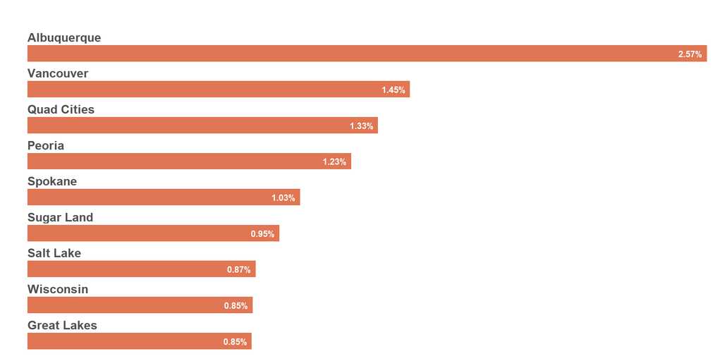

```r
  viz_hts_yield <-
    df_viz %>%
    mutate(psnu = fct_reorder(psnu, -HTS_TST_YIELD)) %>%
    ggplot(aes(y = psnu)) +
    geom_col(aes(x = HTS_TST_YIELD), fill = burnt_sienna, width = 1, show.legend = T) +
    geom_text(aes(x = HTS_TST_YIELD, label = percent(HTS_TST_YIELD, .01)),
              fontface = "bold", color = "#FFF", size = 3, hjust = 1.2) +
    scale_x_continuous(labels = percent, position = "top", expand = c(0, 0)) +
    scale_y_discrete(guide = "none") +
    facet_wrap(~psnu, ncol = 1, scales = "free_y") +
    labs(x = "", y = "") +
    si_style_transparent() +
    theme(panel.grid.major.x = element_blank(),
          panel.grid.major.y = element_blank(),
          panel.spacing = unit(.2, "lines"),
          axis.text = element_blank(),
          plot.title = element_markdown(),
          plot.subtitle = element_markdown(),
          strip.text = element_text(
            hjust = 0,
            margin = margin(1, 0, 1, 0),
            size = rel(1.1),
            face = "bold"
          ))

  viz_hts_yield
```

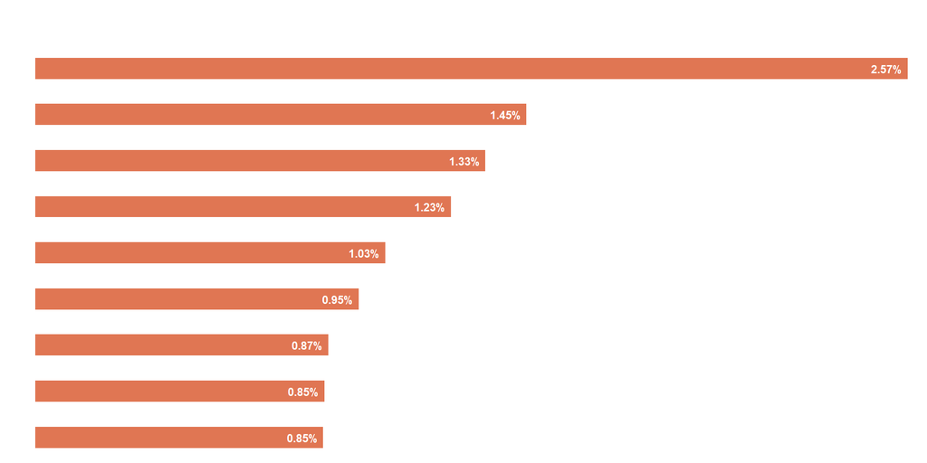

```r
  ## Change the psnu names to white for image overlay
  viz_hts_yield2 <-
    df_viz %>%
    mutate(psnu = fct_reorder(psnu, -HTS_TST_YIELD)) %>%
    ggplot(aes(y = psnu)) +
    geom_col(aes(x = HTS_TST_YIELD), fill = burnt_sienna, width = 1, show.legend = T) +
    geom_text(aes(x = HTS_TST_YIELD, label = percent(HTS_TST_YIELD, .01)),
              fontface = "bold", color = "#FFF", size = 3, hjust = 1.2) +
    scale_x_continuous(labels = percent, position = "top", expand = c(0, 0)) +
    scale_y_discrete(guide = "none") +
    facet_wrap(~psnu, ncol = 1, scales = "free_y") +
    labs(x = "", y = "") +
    si_style_transparent() +
    theme(panel.grid.major.x = element_blank(),
          panel.grid.major.y = element_blank(),
          panel.spacing = unit(.2, "lines"),
          axis.text = element_blank(),
          plot.title = element_markdown(),
          plot.subtitle = element_markdown(),
          strip.text = element_text(
            hjust = 0,
            margin = margin(1, 0, 1, 0),
            size = rel(1.1),
            face = "bold",
            color = "#fff"
          ))

  viz_hts_yield2
```

### 2) Combine multiple plot into 1

There are multiple ways of combining plots. We will focus on 2 packages that we’ve used on a regular basis: `patchwork` and `cowplot`.

#### a) Combine plot with `PATCHWORK`

With patchwork, we can use **+** and **/** to combine plots by row or column. This package will also help with all sort of `plot annotations`.

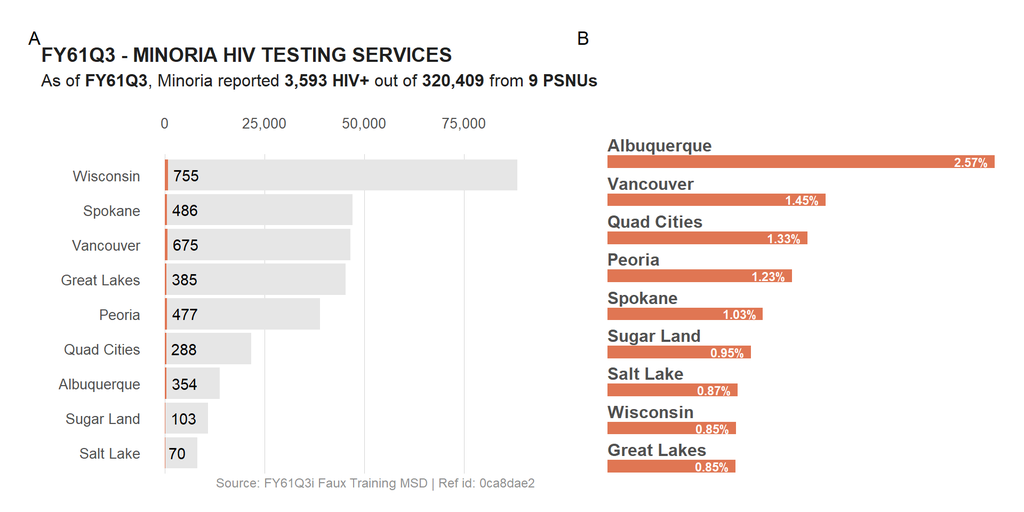

```r
  (viz_hts_pos + viz_hts_yield) +
    plot_annotation(tag_levels = "A")
```

Noticed that the enumeration tags are above the header of plot #A? Let fix that by removing the header from the first plot and adding it back on top of the combined plot.

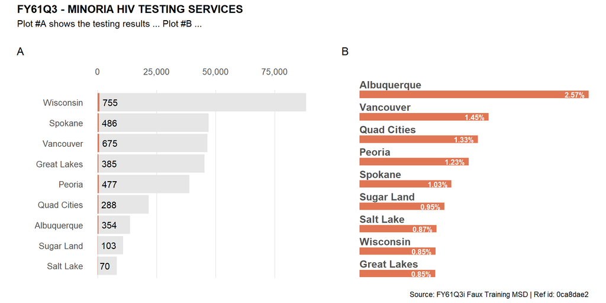

```r
(viz_hts_pos + theme(plot.title = element_blank(),
                     plot.subtitle = element_blank(),
                     plot.caption = element_blank()) +
  viz_hts_yield) +
    plot_annotation(tag_levels = "A") +
    plot_annotation(title = plot_title,
                    subtitle = "Plot #A shows the testing results ... Plot #B ...",
                    caption = meta$caption,
                    theme = theme(plot.title = element_text(face = "bold")))
```

Let’s now combine 3 plots while making sure the last 2 are on the second row.

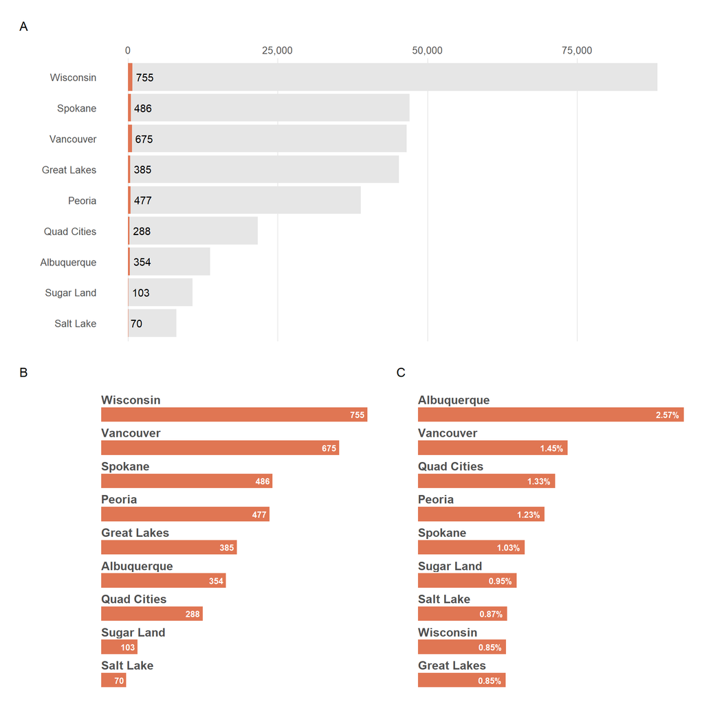

```r
  (
    viz_hts_pos +
     theme(plot.title = element_blank(),
           plot.subtitle = element_blank(),
           plot.caption = element_blank())
  ) /
  (viz_hts_pos2 + viz_hts_yield) +
    plot_annotation(tag_levels = "A")
```

#### b) Combine plot with `COWPLOT`

With `COWPLOT` we can use `ggdraw()` & `draw_plot()` to combine plots. The draw_plot() will overlay plots on top of each other. This is why we needed to apply some transparency to some of the initial plots.

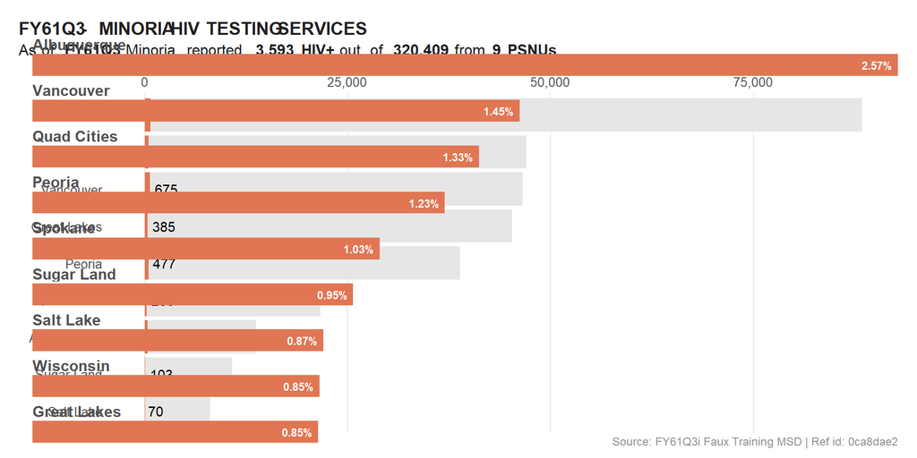

```r
  ggdraw() +
    draw_plot(viz_hts_pos) +
    draw_plot(viz_hts_yield)
```

The overlay was successful but not really useful for the users / readers. To fix this, we will use the location and size parameters to adjust the overlap.

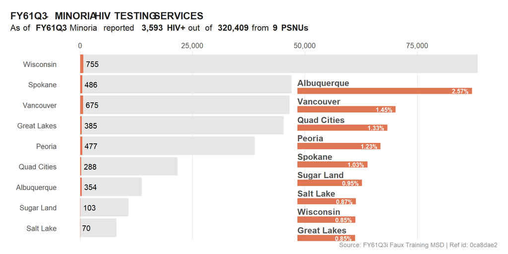

```r
  ggdraw(viz_hts_pos) +
    #draw_plot() +
    draw_plot(viz_hts_yield,
              x = .55, y = 0.02,
              width = .4, height = .75)
```

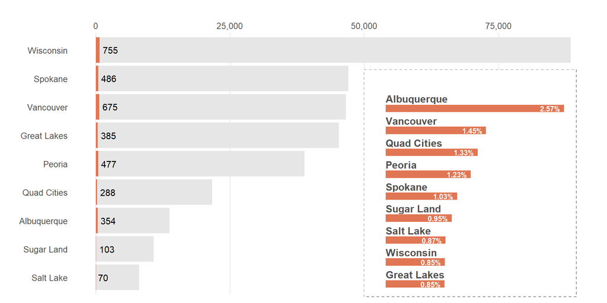

```r
  viz_hts_viz <- ggdraw() +
    draw_plot(viz_hts_pos +
                theme(plot.title = element_blank(),
                      plot.subtitle = element_blank(),
                      plot.caption = element_blank())) +
    draw_plot(viz_hts_yield +
                theme(plot.background = element_rect(color = trolley_grey,
                                                     fill = "#FFFFFF",
                                                     linetype = "dashed")),
              x = .6, y = 0.02,
              width = .35, height = .75)

  viz_hts_viz
```

The overlay is looking better now. How do we put back out title? `Cowplot` has a `plot_grid()` function we can leverage. This is similar to `pathwork`.

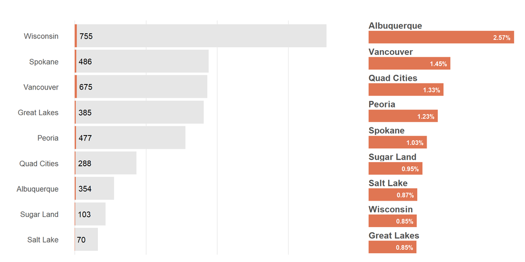

```r
  plot_grid(viz_hts_pos +
              theme(plot.title = element_blank(),
                    plot.subtitle = element_blank(),
                    plot.caption = element_blank(),
                    axis.text.x = element_blank()),
            viz_hts_yield,
            rel_widths = c(2, 1))
```

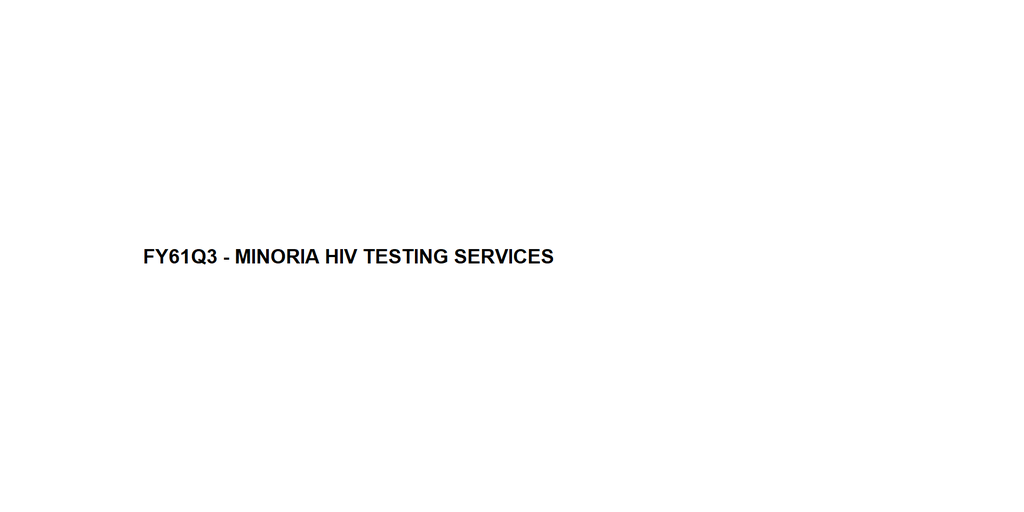

```r
title <- ggdraw() +
  draw_label(
    label = plot_title,
    fontface = 'bold',
    x = 0,
    hjust = 0
  ) +
  theme(plot.margin = margin(0, 0, 0, 7, unit = "lines")) # Add some space to left

title
```

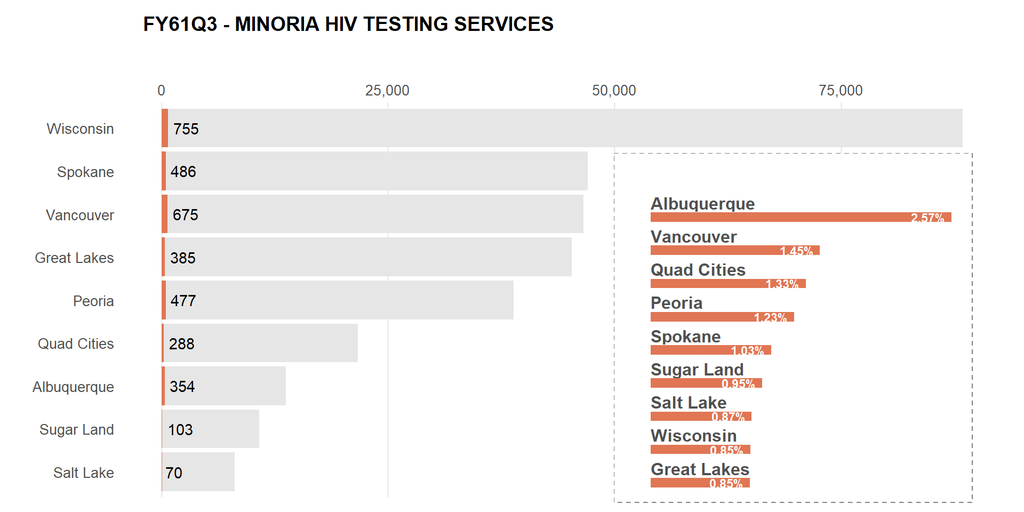

```r
 plot_grid(title,
           viz_hts_viz,
           ncol = 1,
           rel_heights = c(0.1, 1)) # Shrink plots before combining them
```

### 3) Add ggplot plots to images (png files)

#### a) Read and Visualize Images

[figure not shown]

```r
  ## Read image file as a raster data
  logo <- png::readPNG("../figures/logo.png") %>%
    grid::rasterGrob()

  ggdraw() + draw_grob(logo) # visualize a raw data of an image
```

[figure not shown]

```r
  # Visualize an image
  ggdraw() +
    draw_image("../figures/logo.png")
```

[figure not shown]

```r
  # Visualize an image hosted online
  ggdraw() +
    draw_image(file_logo)
```

[figure not shown]

```r
  # Visualize an image hosted online
  ggdraw() +
    draw_image("usaid-pptx-header.png")
```

#### b) Adding ggplot plot on top of image

[figure not shown]

```r
  # Image will be place at the center of canvas by default
  ggdraw() +
    draw_image("../figures/logo.png") +
    draw_plot(viz_hts_yield,
              x = 0, y = 0,
              width = 1, height = 1)
```

[figure not shown]

```r
  ## Re-position of the image
  ggdraw() +
    draw_image("../figures/logo.png",
               halign = 1,
               valign = .5) +
    draw_plot(viz_hts_yield,
              x = 0, y = 0,
              width = 1, height = 1)
```

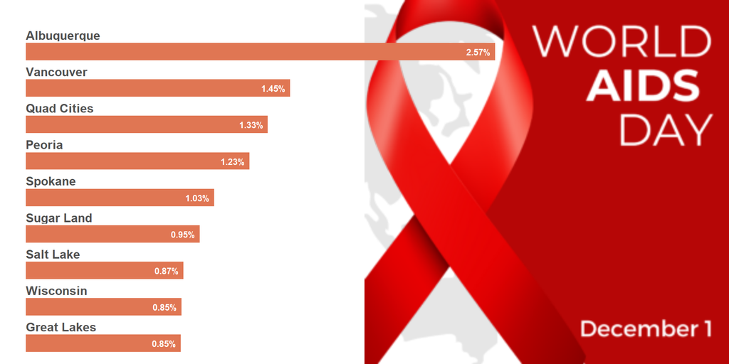

```r
  # Adjust both image and plot to ideal locations
  ggdraw() +
    draw_image(file_aids, halign = 1, valign = .5) +
    draw_plot(viz_hts_yield,
              x = 0, y = 0,
              width = .7, height = 1)
```

[figure not shown]

```r
  # Playing attention to color combination / contrast
  ggdraw() +
    draw_image("usaid-pptx-header.png",
               halign = 0, valign = .5) +
    draw_plot(viz_hts_yield2,
              x = .45, y = .08,
              width = .55, height = .8)
```

### 4) Add images (png files) to ggplot plots

Using ggplot `annotation_custom()` we could also add raw images to specific areas of a plot.

[figure not shown]

```r
  # Logo at the bottom right
  viz_hts_pos +
    annotation_custom(
      grob = logo,
      xmin = max(df_viz$HTS_TST) - 10000,
      xmax = max(df_viz$HTS_TST) + (10000 - 1000),
      ymin = 1, ymax = 3)
```

[figure not shown]

```r
  # Logo in the middle of the plot
  viz_hts_pos +
    annotation_custom(
      grob = logo,
      xmin = max(df_viz$HTS_TST) /2 - 10000,
      xmax = max(df_viz$HTS_TST) /2 + (10000 - 1000),
      ymin = 4, ymax = 6
    ) +
    theme()
```

[figure not shown]

```r
  # Logo at the top right of the plot
  viz_hts_pos +
    annotation_custom(
      grob = logo,
      xmin = max(df_viz$HTS_TST) - 10000,
      xmax = max(df_viz$HTS_TST) + (10000 - 1000),
      ymin = 8, ymax = Inf
    ) +
    theme()
```

[figure not shown]

```r
# Re-position the header
viz_hts_pos_shift_header <- viz_hts_pos +
  theme(plot.title = element_markdown(hjust = .35),
        plot.subtitle = element_markdown(hjust = .5))

# Add the logo at the top left corner
ggdraw() +
    draw_plot(viz_hts_pos_shift_header) +
    draw_image("../figures/logo.png",
              x = .04, y = .82,
              width = .15, height = .15) +
    theme(plot.title = element_markdown(hjust = 0, linewidth = unit(20, "lines")))
```

[figure not shown]

```r
  # use of image as label
  logo <- ggdraw() +
    draw_image("../figures/corps.png", scale = 1, width = .5)

  title2 <- ggdraw() +
    draw_label(
      label = plot_title,
      fontface = 'bold',
      x = 0,
      hjust = 0
    ) +
    theme(plot.margin = margin(0, 0, 0, 0)) # No spaces

  # Image and title together
  header <- plot_grid(logo, title2, rel_widths = c(1,4))

  plot_grid(header,
            viz_hts_viz,
            ncol = 1,
            rel_heights = c(0.1, 1)) # Shrink plots before combining them
```

## Additional notes

`fontawesome` has some great fonts that can be used and labels or saved as images.

```r
  # Get font metadata
  fa_meta <- fontawesome::fa_metadata()
  #fa_meta$icon_names
  fa_meta$icon_count
```

[output not shown]

[figure not shown]

```r
  # Save fonts as images
  #fontawesome::fa(name = "r-project")

  # Download font
  fontawesome::fa_png(name = "r-project")
  # plot font image
  ggdraw() + draw_image("r-project.png")
```

[figure not shown]

```r
  #font awesome::fa(name = "fab fa-youtube")

  # Download font with specific color
  fontawesome::fa_png(name = "fab fa-youtube", fill = usaid_red)

  # plot font image
  ggdraw() + draw_image("youtube.png")
```

## HAPPY PLOTTING… :)

## For feature inquiries, use [github issues](https://github.com/USAID-OHA-SI/coRps/issues) …